# Quality Control: Filtering & Trimming Amplicon Sequences

Hilal Samut

March 11, 2025

# Goals of this file

Output that we will create in this file:

1. Quality plots to asses pre- and post-quality trimming.
2. Written files that include the filtered and trimmed data. (Note that this will be written during the `filterAndTrim()` function.)

# Set the Seed

```r
# any number can be chosen
set.seed(128)
```

### Timing of Script

```r
# What time did we start running this script?
start_time <- Sys.time()
start_time
```

```
## [1] "2025-03-11 12:49:17 EDT"
```

# Load R libraries

```r
# Efficiently load with pacman
pacman::p_load(tidyverse, dada2, phyloseq, DT, devtools, patchwork, install = FALSE)
```

# Reading Raw Sequencing Files

```r
# Set the raw fastq path to the raw sequencing files
# Path to the fastq files
raw_fastqs_path <- "data/01_DADA2/01_raw_gzipped_fastqs"
raw_fastqs_path
```

```
## [1] "data/01_DADA2/01_raw_gzipped_fastqs"
```

```r
# What files are in this path? Intuition Check
head(list.files(raw_fastqs_path))
```

```
## [1] "SRR17327669_1.fastq.gz" "SRR17327669_2.fastq.gz" "SRR17327670_1.fastq.gz"
## [4] "SRR17327670_2.fastq.gz" "SRR17327671_1.fastq.gz" "SRR17327671_2.fastq.gz"
```

```r
# How many files are there?
length(list.files(raw_fastqs_path))
```

```
## [1] 216
```

```r
# Create vector of forward reads
forward_reads <- list.files(raw_fastqs_path, pattern = "1.fastq.gz", full.names = TRUE)

# Intuition Checks
head(forward_reads)
```

```
## [1] "data/01_DADA2/01_raw_gzipped_fastqs/SRR17327669_1.fastq.gz"
## [2] "data/01_DADA2/01_raw_gzipped_fastqs/SRR17327670_1.fastq.gz"
## [3] "data/01_DADA2/01_raw_gzipped_fastqs/SRR17327671_1.fastq.gz"
## [4] "data/01_DADA2/01_raw_gzipped_fastqs/SRR17327672_1.fastq.gz"
## [5] "data/01_DADA2/01_raw_gzipped_fastqs/SRR17327673_1.fastq.gz"
## [6] "data/01_DADA2/01_raw_gzipped_fastqs/SRR17327674_1.fastq.gz"
```

```r
# Intuition check #2: We should have fewer reads in the forward vector than in total
stopifnot(length(forward_reads) < length(list.files(raw_fastqs_path)))

# Create a vector of reverse reads
reverse_reads <- list.files(raw_fastqs_path, pattern = "2.fastq.gz", full.names = TRUE)

# Intuition Checks
head(reverse_reads)
```

```
## [1] "data/01_DADA2/01_raw_gzipped_fastqs/SRR17327669_2.fastq.gz"
## [2] "data/01_DADA2/01_raw_gzipped_fastqs/SRR17327670_2.fastq.gz"
## [3] "data/01_DADA2/01_raw_gzipped_fastqs/SRR17327671_2.fastq.gz"
## [4] "data/01_DADA2/01_raw_gzipped_fastqs/SRR17327672_2.fastq.gz"
## [5] "data/01_DADA2/01_raw_gzipped_fastqs/SRR17327673_2.fastq.gz"
## [6] "data/01_DADA2/01_raw_gzipped_fastqs/SRR17327674_2.fastq.gz"
```

```r
# Intuition check #2: Need to have equal number of forward and reverse files
stopifnot(length(reverse_reads) == length(forward_reads))
```

# Assess Raw Read Quality

## Evaluate raw sequence quality

Let’s see the quality of the raw reads *before* we trim

## Plot 12 random samples of plots

```r
# Randomly select 12 samples from dataset to evaluate
# Selecting 12 is typically better than 2 (like we did in class for efficiency)
random_samples <- sample(1:length(reverse_reads), size = 12)
random_samples
```

```
##  [1]  4 18 82 54 70 89 35 27 56 72 74 68
```

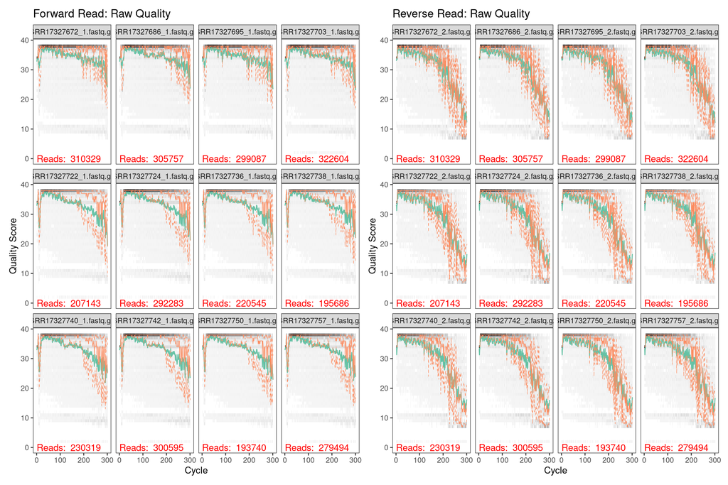

```r
# Calculate and plot quality of these two samples
forward_filteredQual_plot_12 <- plotQualityProfile(forward_reads[random_samples]) +
  labs(title = "Forward Read: Raw Quality")
reverse_filteredQual_plot_12 <- plotQualityProfile(reverse_reads[random_samples]) +
  labs(title = "Reverse Read: Raw Quality")
library(patchwork)
# Plot them together with patchwork
forward_filteredQual_plot_12 + reverse_filteredQual_plot_12
```

## Aggregated Raw Quality Plots

Next, we will plot all of the samples aggregated into one forward (left) and one reverse read (right) plot.

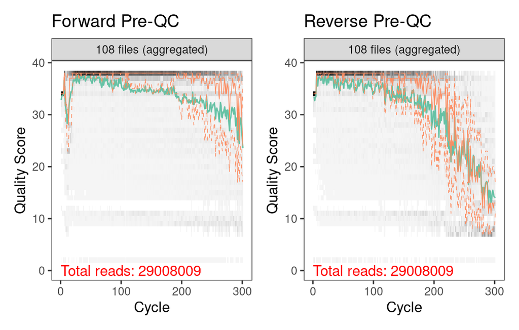

```r
# Aggregate all QC plots
# Forward reads
forward_preQC_plot <-
  plotQualityProfile(forward_reads, aggregate = TRUE) +
  labs(title = "Forward Pre-QC")

# reverse reads
reverse_preQC_plot <-
  plotQualityProfile(reverse_reads, aggregate = TRUE) +
  labs(title = "Reverse Pre-QC")

# Now, let's put the two plots together
preQC_aggregate_plot <-
  # Plot the forward and reverse together
  forward_preQC_plot + reverse_preQC_plot
# Show the plot
preQC_aggregate_plot
```

Above are plots showing the pre-QC quality scores of the raw sequencing data for the project. We can draw a few conclusions from the plots above, which were generated with 2x300 bp sequencing on an Illumina MiSeq Sequencer:

1. *Early Bases have a drop in quality (~Cycle/Bases 0-10):*
   - **Forward reads** have slightly lower quality at early cycles at positions ~5 bp. However, the quality scores are still above ~25. I think most of the reads at these positions have enough quality to be retained in downstream analysis.
   - **Reverse reads** sustain more than Q30 at early cycles. That’s why no need for trim.
2. *High Quality in Mid-Bases (~10-200 Cycles/Bases):*
   - **Forward reads** have quality scores that are stable and above Q30 across most of the sequencing cycle/read with a slight decline in quality as the number of cycles increases, yet they are still at good quality.
   - This suggests that most of the read length is high-quality and can be retained.
   - The quality in **Reverse reads** starts to decline slightly at position ~185 bp. However, the quality scores are still above ~Q25.
3. *Decline in Reverse Reads After ~185 Cycles/Bases:*
   - The quality in reverse reads declines more quickly than in forward reads.
   - After ~185 bp, reverse reads show a slight drop below Q30. After ~220 bp, quality drops below Q25.
   - After ~250bp, quality in reverse reads continues to drop below Q20, indicating high sequencing error rates.
     - This is also what we observed in FastQC and MultiQC reports for half of the reads that I have in my dataset. The pre-QC plot created here using only reverse reads also proves that the decline in quality observed in MultiQC report was due to reverse reads.
   - **Solution**: I will truncate the reverse reads using `truncLen = 210` to remove poor quality bases observed in reverse reads less than Q30 after position ~210 bp.
4. *Forward Reads Also Show Decline in Quality After ~250 bp*
   - Forward reads degrade after ~260 cycles, but the quality drop is less severe than in reverse reads.
   - **Solution**: Similar to reverse reads, I will truncate the forward reads using `truncLen = 260` to remove poor quality bases observed in reverse reads less than Q30 after position ~250 bp.

#### Prepare a placeholder for filtered reads

```r
# Create vector of sample names from the filenames
sample_names <- sapply(strsplit(basename(forward_reads), "_"), `[`,1)

# Intuition Check
head(sample_names)
```

```
## [1] "SRR17327669" "SRR17327670" "SRR17327671" "SRR17327672" "SRR17327673"
## [6] "SRR17327674"
```

```r
# Place filtered reads into filtered_fastqs_path
filtered_fastqs_path <- "data/01_DADA2/02_filtered_fastqs"

# Intuition Check
filtered_fastqs_path
```

```
## [1] "data/01_DADA2/02_filtered_fastqs"
```

```r
# create 2 vectors: filtered_forward_reads & filtered_reverse_reads
filtered_forward_reads <-
  file.path(filtered_fastqs_path, paste0(sample_names, "_R1_filtered.fastq.gz"))

# Intuition Check
length(filtered_forward_reads)
```

```
## [1] 108
```

```r
# reverse reads
filtered_reverse_reads <-
  file.path(filtered_fastqs_path, paste0(sample_names, "_R2_filtered.fastq.gz"))

# Intuition Check
head(filtered_reverse_reads)
```

```
## [1] "data/01_DADA2/02_filtered_fastqs/SRR17327669_R2_filtered.fastq.gz"
## [2] "data/01_DADA2/02_filtered_fastqs/SRR17327670_R2_filtered.fastq.gz"
## [3] "data/01_DADA2/02_filtered_fastqs/SRR17327671_R2_filtered.fastq.gz"
## [4] "data/01_DADA2/02_filtered_fastqs/SRR17327672_R2_filtered.fastq.gz"
## [5] "data/01_DADA2/02_filtered_fastqs/SRR17327673_R2_filtered.fastq.gz"
## [6] "data/01_DADA2/02_filtered_fastqs/SRR17327674_R2_filtered.fastq.gz"
```

# Filter and Trim Reads

```r
# Assign and write out filtered fastq files
filtered_reads <-
  filterAndTrim(fwd = forward_reads, filt = filtered_forward_reads,
              rev = reverse_reads, filt.rev = filtered_reverse_reads,
              maxN = 0, maxEE = c(2, 2),
              # Remove the bases after 260 and 210 in forward and reverse reads, respectively, with truncLen, and primers and low quality bases at the beginning of the forward reads using trimLeft = c(22, 21) - fwd primer is 17 bp long, but there is also ~5 bases at the beginning of the fwd reads with slightly low quality so I trimmed 22 bp from the beginning of fwd reads.
              truncLen = c(260, 210), trimLeft = c(22, 21),
              truncQ = 2, rm.phix = TRUE, compress = TRUE, multithread = 10)
```

# Assess Trimmed Read Quality

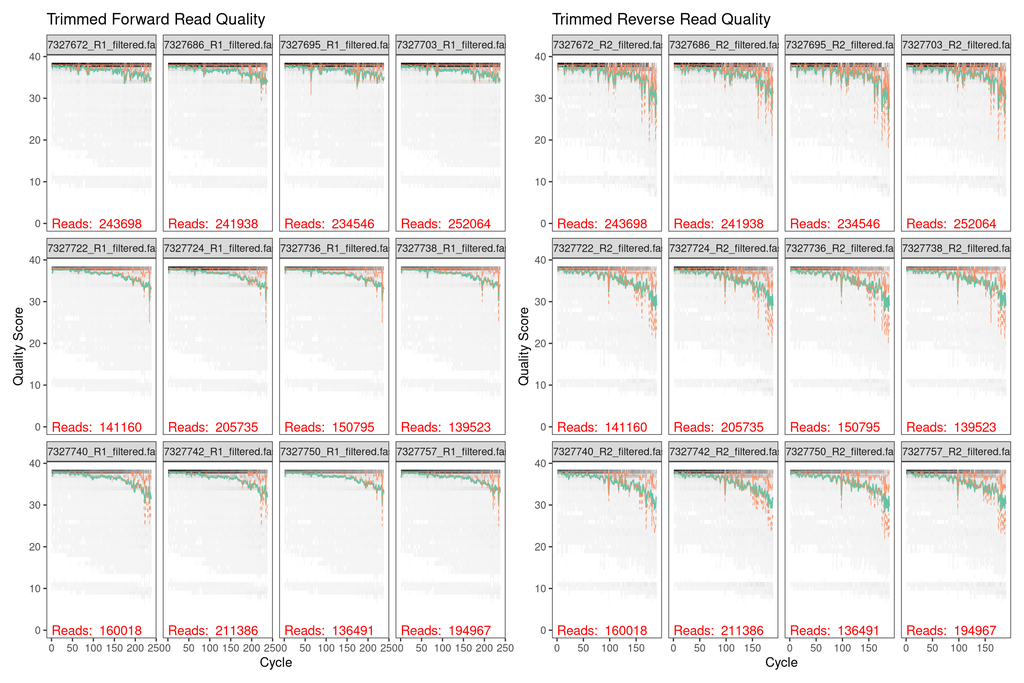

```r
# Plot the 12 random samples after QC
forward_filteredQual_plot_12 <-
  plotQualityProfile(filtered_forward_reads[random_samples]) +
  labs(title = "Trimmed Forward Read Quality")

reverse_filteredQual_plot_12 <-
  plotQualityProfile(filtered_reverse_reads[random_samples]) +
  labs(title = "Trimmed Reverse Read Quality")

# Put the two plots together
forward_filteredQual_plot_12 + reverse_filteredQual_plot_12
```

## Aggregated Trimmed Plots

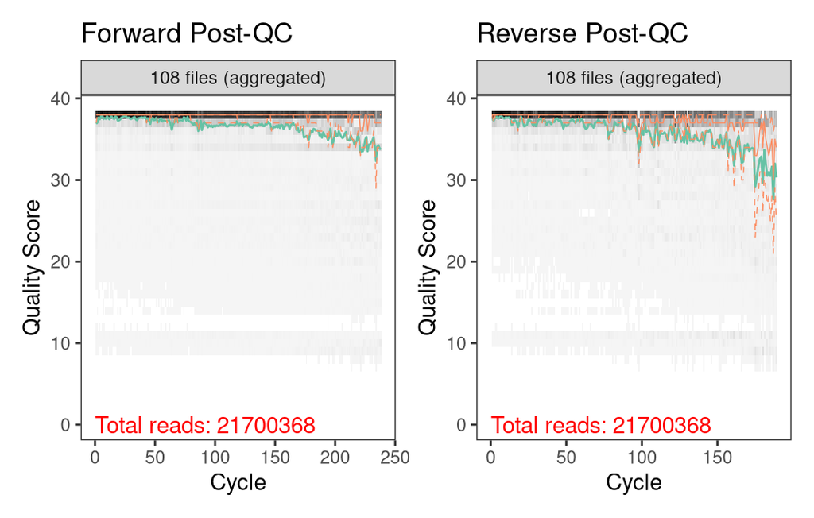

```r
# Aggregate all QC plots
# Forward reads
forward_postQC_plot <-
  plotQualityProfile(filtered_forward_reads, aggregate = TRUE) +
  labs(title = "Forward Post-QC")

# reverse reads
reverse_postQC_plot <-
  plotQualityProfile(filtered_reverse_reads, aggregate = TRUE) +
  labs(title = "Reverse Post-QC")

# Now, let's put the two plots together
postQC_aggregate_plot <-
  # Plot the forward and reverse together
  forward_postQC_plot + reverse_postQC_plot

# Show the plot
postQC_aggregate_plot
```

This post-QC quality score plot from 108 aggregated Illumina sequencing files shows the forward (left) and reverse (right) reads after quality filtering and trimming.

**Takeaway:** Quality filtering successfully retained high-quality bases while removing low-quality tails.

To further confirm that things look ok, let’s take a look at the read retention of our QC step.

## Read Retention Post-QC

```r
# Make output into dataframe
filtered_df <- as.data.frame(filtered_reads) %>%
  mutate(percent.retained = reads.out/reads.in)

# Intuition check
# Visualize it in table format
DT::datatable(filtered_df)
```

|  | reads.in | reads.out | percent.retained |
| --- | --- | --- | --- |
| SRR17327669_1.fastq.gz | 309915 | 237469 | 0.7662391300840553 |
| SRR17327670_1.fastq.gz | 302390 | 235650 | 0.7792916432421707 |
| SRR17327671_1.fastq.gz | 352752 | 275362 | 0.7806107406903433 |
| SRR17327672_1.fastq.gz | 310329 | 243698 | 0.7852891608583149 |
| SRR17327673_1.fastq.gz | 310344 | 242980 | 0.7829376433892713 |
| SRR17327674_1.fastq.gz | 370585 | 293088 | 0.7908792854540794 |
| SRR17327675_1.fastq.gz | 308665 | 244867 | 0.7933098990815285 |
| SRR17327676_1.fastq.gz | 267844 | 211242 | 0.7886754976777527 |
| SRR17327677_1.fastq.gz | 267367 | 211083 | 0.7894878575142034 |
| SRR17327678_1.fastq.gz | 294083 | 227895 | 0.7749342872590391 |

[output cut: 98 more lines]

```r
# Let's calculate some statistics
read_stats_df <-
  filtered_df %>%
  reframe(median_reads_in = median(reads.in),
          median_reads_out = median(reads.out),
          median_percent_retained = (median(reads.out)/median(reads.in)),
          max_percent_retained = max(reads.out/reads.in),
          min_percent_retained = min(reads.out/reads.in))

# Take a look at it!
read_stats_df
```

```
##   median_reads_in median_reads_out median_percent_retained max_percent_retained
## 1        275918.5         204337.5               0.7405719            0.8055923
##   min_percent_retained
## 1            0.6599252
```

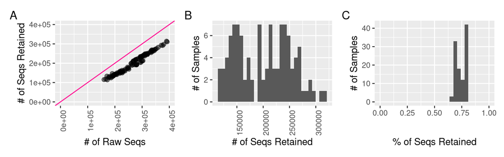

```r
# Plot it
numSeqs_QC_dotplot <-
  filtered_df %>%
  ggplot(aes(x = reads.in, y = reads.out)) +
  geom_point(alpha = 0.5, size = 2) +
  labs(x = "# of Raw Seqs",
       y = "# of Seqs Retained") +
  xlim(0, 400000) +
  ylim(0, 400000) +
  theme(axis.text.x = element_text(angle = 90, hjust = 1)) +
  # Now let's add a 1:1 line for reference of keeping 100% of the reads
  geom_abline(slope=1, intercept = 0, color = "deeppink")

# Now, let's look at the number of reads retained in a histogram
numRetained_QC_histplot <-
  filtered_df %>%
  ggplot(aes(x = reads.out)) +
  geom_histogram() +
  labs(x = "# of Seqs Retained",
       y = "# of Samples") +
  theme(axis.text.x = element_text(angle = 90, hjust = 1))

# Create a histogram of percent reads retained in a histogram
percSeqs_QC_histplot <-
  filtered_df %>%
  ggplot(aes(x = percent.retained)) +
  geom_histogram() +
  labs(x = "% of Seqs Retained",
       y = "# of Samples") +
  # Set the scale to be between 0-1 (0-100%)
  scale_x_continuous(limits = c(0, 1))

# Now, let's put the plots together
numSeqs_QC_dotplot + numRetained_QC_histplot + percSeqs_QC_histplot +
  plot_annotation(tag_levels = 'A')
```

This figure presents three panels showing how many sequences were retained after quality filtering and trimming in the DADA2 pipeline. Let’s break down each panel:

**Panel A: Scatter Plot of Raw vs. Retained Sequences:**

- X-axis: Number of raw sequences before filtering.
- Y-axis: Number of sequences retained after filtering.
- Pink Line: The diagonal line represents perfect retention (i.e., no sequences lost).

*Interpretation of Panel A:*

- All the points slightly fall far away from the diagonal, meaning there might be information loss in all of the samples during filtering.
- No extreme outliers, meaning no sample lost an excessive number of reads unexpectedly. Overall, retention of reads aren’t perfect due to excessive truncation at the end of reads. I used `maxEE = c(1, 1)` in the first filtering, then, changed it to `maxEE = c(2, 2)`. However, still the retention of reads after trimming is average. I didn’t want to change the truncation lengths to stick with methodology followed in the paper and to keep the bases with quality scores >30.

**Panel B: Histogram of the Number of Sequences Retained per Sample**

- X-axis: Number of sequences retained per sample.
- Y-axis: Number of samples with that many retained sequences.

*Interpretation of Panel B*

- The majority of samples have between ~125,000 and 250,000 retained sequences.
- There are two spikes at ~150,000 and 250,000.
- Overall, most samples retained a high number of sequences as the number of reads are high.

**Panel C: Histogram of Percent of Sequences Retained**

- X-axis: Proportion (%) of sequences retained per sample.
- Y-axis: Number of samples at each proportion.

*Interpretation of Panel C*.

### Visualize QC differences in plot

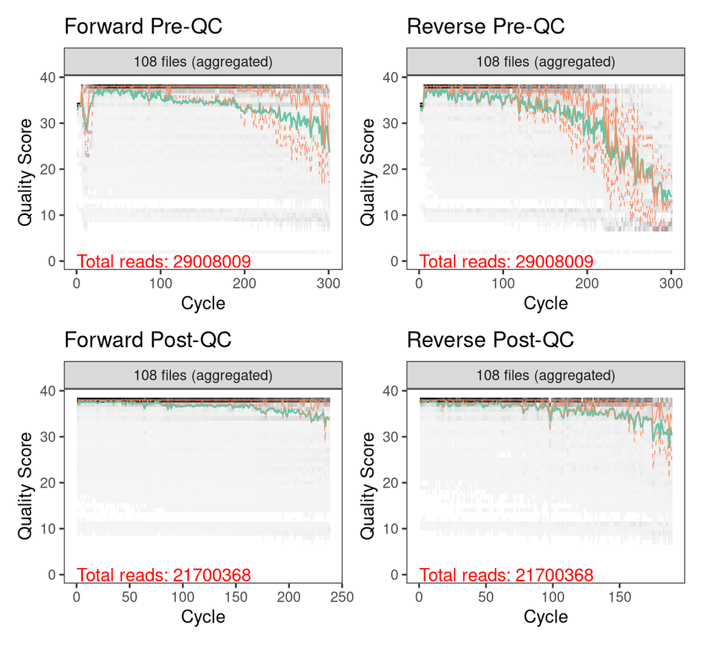

```r
# Plot the pre and post together in one plot
preQC_aggregate_plot / postQC_aggregate_plot
```

**Quality Score Improvements**

# Check Render Time

```r
# Take the time now that we are at the end of the script
end_time <- Sys.time()
end_time
```

```
## [1] "2025-03-11 13:33:48 EDT"
```

```r
# Echo the elapsed time
elapsed_time <- round((end_time - start_time), 3)
elapsed_time
```

```
## Time difference of 44.516 mins
```